# 成為初級資料分析師 | Python 機器學習

> 梯度遞減（Gradient Descent）

## 郭耀仁

## 大綱

- 關於梯度遞減
- 計算複雜性
- 進階的梯度遞減

## 關於梯度遞減

## 我們目前已經會使用兩種方法在給定 $h = Xw$ 的前提之下，尋找最佳的 $w$

- `sklearn.linear_model`
- 自行撰寫正規方程（normal equations）

## 除了前述這兩種方法以外，還有第三種方法稱為梯度遞減（Gradient Descent），同樣能夠在給定 $h = Xw$ 的前提之下，尋找最佳的 $w$

## 什麼是梯度遞減？

> 梯度遞減是一種透過「迭代」實踐最佳化的演算法，利用一組隨機賦予的 $w$ 作為起始，計算該點每個 $w_i$ 對成本函數偏微分的斜率，並依照偏微分斜率的正負值與學習速率，決定目前的 $w$ 應該減少或者增加多少，在適當的學習速率設定下，經過足夠次數的迭代後可以得到一組逼近成本函數最小的係數組合 $w$。

## 讓我們先將 $h$ 簡化為只有 $w_1$：

$$h(x_1) = w_1x_1$$

## 給定一組 $x_1$ 與 $y$

```python
print(x_1)
print(y)
```

```
[ 1  2  3  4  5  6  7  8  9 10]
[ 3  6  9 12 15 18 21 24 27 30]
```

## 假設我們看不出來 $w_1 =3$

## 所以在 1 到 5 之間窮舉了 100 個 $w_1$，將每個 $w_1$ 帶入成本函數 MSE 中計算

$$MSE_{train} = \frac{1}{m}\sum_i(\hat{y}^{(train)} - y^{(train)})_i^2$$

```python
x_1 = np.arange(1, 11)
y = np.arange(3, 33, 3)
m = y.size
w_1_arr = np.linspace(1, 5, 100)
mses = []
for i in w_1_arr:
    y_hat = x_1*i
    mse = (((y_hat - y)**2).sum())/m
    mses.append(mse)
```

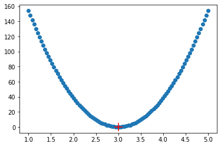

```python
import matplotlib.pyplot as plt

fig = plt.figure()
ax = plt.axes()
ax.scatter(w_1_arr, mses)
ax.scatter(3, 0, marker="+", s=200, c="r")
plt.show()
```

## 在我們窮舉的 100 個 $w_1$ 之中第 49 個 $w_1$ 能夠讓 MSE 最低

```python
min_index = mses.index(min(mses))
print(min_index)
print(w_1_arr[min_index])
```

```
49
2.97979797979798
```

## 這個做法是對的嗎？

## 不過是運氣好在一個有包含 $w_1 = 3$ 的區間窮舉而已，假如在其他區間窮舉 100 個 $w_1$，像是 5 到 9

```python
x_1 = np.arange(1, 11)
y = np.arange(3, 33, 3)
m = y.size
w_1_arr = np.linspace(5, 9, 100)
mses = []
for i in w_1_arr:
    y_hat = x_1*i
    mse = (((y_hat - y)**2).sum())/m
    mses.append(mse)
```

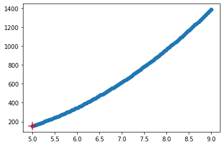

```python
fig = plt.figure()
ax = plt.axes()
ax.scatter(w_1_arr, mses)
y_hat = x_1*5
mse = (((y_hat - y)**2).sum())/m
ax.scatter(5, mse, marker="+", s=200, c="r")
plt.show()
```

## 在我們窮舉的 100 個 $w_1$ 之中第 0 個 $w_1$ 能夠讓 MSE 最低，但並不是理想中的 $w_1 = 3$

```python
min_index = mses.index(min(mses))
print(min_index)
print(w_1_arr[min_index])
```

```
0
5.0
```

## 梯度遞減的演算法就是為了因應這樣窮舉式、大海撈針式的找 $w_1$ 方法

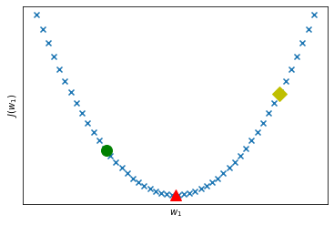

```python
get_gd_plot()
```

## 何謂有意識地、在窮舉的 $w_1$ 中向正確的方向修正？

- $w_1$ 位於綠圓點，$\frac{\mathrm \partial}{\mathrm \partial w_1} J(w_1)$ 為負值，$w_1$ 應該要向右邊修正
- $w_1$ 位於黃方塊，$\frac{\mathrm \partial}{\mathrm \partial w_1} J(w_1)$ 為正值，$w_1$ 應該要向左邊修正
- $w_1$ 位於紅三角，$\frac{\mathrm \partial}{\mathrm \partial w_1} J(w_1)$ 為零，$w_1$ 應該要停止修正，收斂

## 第三種找出 $w$ 的方法：梯度遞減（Gradient Descent）指的就是從隨機指定的 $w_1$ 起始透過迭代、有意識地朝 $w_1^*$ 修正、更新

$$ w_1 := w_1 - \alpha \frac{\mathrm \partial}{\mathrm \partial w_1} J(w_1) \\ $$

## $w_1$ 修正的速度與 $\alpha$ 相關，$\alpha$ 稱為學習速率（Learning Rate）

## 有意識地向正確方向修正特定幅度

- $w_1$ 位於綠圓點，$\frac{\mathrm \partial}{\mathrm \partial w_1} J(w_1)$ 為負值，$w_1$ 向右邊修正 $\alpha \frac{\mathrm \partial}{\mathrm \partial w_1} J(w_1)$
- $w_1$ 位於黃方塊，$\frac{\mathrm \partial}{\mathrm \partial w_1} J(w_1)$ 為正值，$w_1$ 向左邊修正 $\alpha \frac{\mathrm \partial}{\mathrm \partial w_1} J(w_1)$
- $w_1$ 位於紅三角，$\frac{\mathrm \partial}{\mathrm \partial w_1} J(w_1)$ 為零，$w_1$ 要停止修正，收斂

## 如何挑選學習速率

- 如果學習速率夠小，成本函數每一次都會下降
- 學習速率太小，收斂的速度太慢
- 學習速率太大，可能會無法收斂

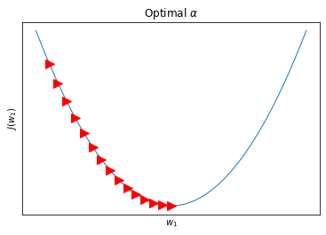

```python
get_optimal_alpha_plot()
```

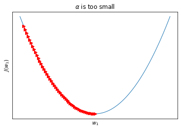

```python
get_small_alpha_plot()
```

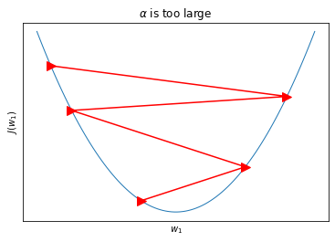

```python
get_large_alpha_plot()
```

## 推導對 $w_1$ 偏微分的成本函數（梯度）

$$ J(w_1) = \frac{1}{m}\sum_i (\hat{y} - y)_i^2 = \frac{1}{m}\sum_i (w_1x_{i1} - y_i)^2 \\ J(w_1) = \frac{1}{m}\sum_i (w_1^2x_{i1}^2-2w_1x_{i1}y_i+y_i^2) \\ \frac{\partial J}{\partial w_1} = \frac{1}{m}\sum_i(2w_1x_{i1}^2 - 2x_{i1}y_i) \\ \frac{\partial J}{\partial w_1} = \frac{2}{m}\sum_i(w_1x_{i1}^2 - x_{i1}y_i) = \frac{2}{m}\sum_i x_{i1}(x_{i1}w_1 - y_i) $$

## 梯度遞減（Gradient Descent）：從隨機指定的 $w_1$ 起始透過迭代、有意識地朝 $w_1^*$ 修正、更新

$$ w_1 := w_1 - \alpha \frac{\mathrm \partial}{\mathrm \partial w_1} J(w_1) \\ w_1 := w_1 - \alpha \frac{2}{m}\sum_i x_{i1}(x_{i1}w_1 - y_i) \\ w_1 := w_1 - \alpha \frac{2}{m}\sum_i x_{i1}(\hat{y_i} - y_i) $$

## 給定 $x_1$ 與 $y$，根據梯度遞減（Gradient Descent）的演算法，利用 1000 次的迭代、$\alpha = 0.0001$ 找出 $w_1$

$$h(x_1) = w_1x_1$$

```python
x_1 = np.arange(1, 11)
y = np.arange(3, 33, 3)
```

```python
def get_grad(X, y, w_1):
    m = y.size
    y_hat = w_1*X
    err = y_hat - y
    grad = (X*(err)).sum()*2/m
    return grad

w_1 = np.random.random(1)[0]
learning_rate = 0.0001
for i in range(1000):
    grad = get_grad(x_1, y, w_1)
    w_1 -= learning_rate*grad
    if i % 100 == 0:
        print("{} iterations: w_1 = {}".format(i, w_1))
```

```
0 iterations: w_1 = 0.7286815129593229
100 iterations: w_1 = 1.9514789075142973
200 iterations: w_1 = 2.515965511811678
300 iterations: w_1 = 2.77655252962026
400 iterations: w_1 = 2.896848730333283
500 iterations: w_1 = 2.9523817189974317
600 iterations: w_1 = 2.9780177142466018
700 iterations: w_1 = 2.989852198005259
800 iterations: w_1 = 2.9953154150355568
900 iterations: w_1 = 2.9978374295930825
```

```python
print(w_1)
```

```
2.9989939341676237
```

## 承接上題，將迭代過程的成本（MSE）記錄起來並作圖

```python
def get_mse(X, y, w_1):
    m = y.size
    err = w_1*X - y
    se = err**2
    sse = se.sum()
    mse = sse / m
    return mse
```

```python
w_1 = np.random.random(1)[0]
learning_rate = 0.0001
j_history = []
w_1_history = []
for i in range(1000):
    grad = get_grad(x_1, y, w_1)
    mse = get_mse(x_1, y, w_1)
    j_history.append(mse)
    w_1 -= learning_rate*grad
    if i % 100 == 0:
        print("{} iterations: w_1 = {}".format(i, w_1))
        w_1_history.append(w_1)
```

```
0 iterations: w_1 = 0.9363690444875622
100 iterations: w_1 = 2.0473548309905225
200 iterations: w_1 = 2.5602252352278083
300 iterations: w_1 = 2.7969843861891124
400 iterations: w_1 = 2.9062807992806015
500 iterations: w_1 = 2.956735896226854
600 iterations: w_1 = 2.9800277567358084
700 iterations: w_1 = 2.990780104839438
800 iterations: w_1 = 2.9957437697084255
900 iterations: w_1 = 2.9980351732878256
```

```python
def get_gd_plots(j_history, w_1_history):
    fig, axes = plt.subplots(1, 2, figsize=(13, 3))
    axes[0].plot(range(len(j_history)), j_history)
    axes[0].set_xlabel("Number of iterations")
    axes[0].set_ylabel("MSE")
    axes[0].set_title("MSE trend")
    axes[1].scatter([i*100 for i in range(len(w_1_history))], w_1_history, marker="+")
    axes[1].scatter(0, w_1_history[0], marker="+", s=150, color="green")
    axes[1].scatter(len(w_1_history)-1, w_1_history[-1], marker="+", s=150, color="red")
    axes[1].set_xlabel("Number of iterations")
    axes[1].set_ylabel("$w_1$")
    axes[1].set_title("How does $w_1$ converge")
    plt.show()
```

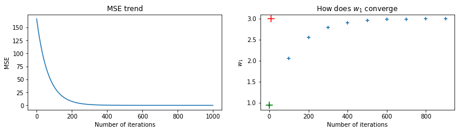

```python
get_gd_plots(j_history, w_1_history)
```

## 接著讓我們將 $w_0$ 加回先前簡化只有 $w_1$ 的 $h$ 之中：

$$h(x_0, x_1) = w_0x_0 + w_1x_1 \text{, where } x_0 = 1$$

## 給定 $x_0$、$x_1$ 與 $y$

```python
print(x_0)
print(x_1)
print(y)
```

```
[1 1 1 1 1 1 1 1 1 1]
[ 1  2  3  4  5  6  7  8  9 10]
[11 17 23 29 35 41 47 53 59 65]
```

## 假設我們看不出來 $w_0=5$ $w_1 =6$

## 透過先前的經驗，我們知道可以利用梯度遞減求 $w_0$ 與 $w_1$

$$ w_0 := w_0 - \alpha \frac{\mathrm \partial}{\mathrm \partial w_0} J(w_0, w_1) \\ w_1 := w_1 - \alpha \frac{\mathrm \partial}{\mathrm \partial w_1} J(w_0, w_1) $$

## 推導對 $w_0$ 與 $w_1$ 偏微分的成本函數（梯度）

$$ J(w_0, w_1) = \frac{1}{m}\sum_i(\hat{y_i} - y_i)^2 = \frac{1}{m}\sum_i(w_0 + w_1x_{i1} - y_i)^2 \\ J(w_0, w_1) = \frac{1}{m}\sum_i\big((w_0 + w_1x_{i1})^2-2(w_0 + w_1x_{i1})y_i+y_i^2\big) \\ J(w_0, w_1) = \frac{1}{m}\sum_i\big(w_0^2+2w_0w_1x_{i1}+w_1^2x_{i1}^2-2(w_0 + w_1x_{i1})y_i+y_i^2\big) \\ \frac{\partial J}{\partial w_0} = \frac{1}{m}\sum_i(2w_0+2w_1x_{i1}-2y_i) = \frac{2}{m}\sum_i(w_0+w_1x_{i1}-y_i) \\ \frac{\partial J}{\partial w_1} = \frac{1}{m}\sum_i(2w_0x_{i1}+2w_1x_{i1}^2-2x_{i1}y_i) = \frac{2}{m}\sum_i(w_0x_{i1}+w_1x_{i1}^2-x_{i1}y_i) = \frac{2}{m}\sum_i x_{i1}(w_0+w_1x_{i1}-y_i) \\ $$

## 梯度遞減（Gradient Descent）：從隨機指定的 $(w_0, w_1)$ 起始透過迭代、有意識地朝 $(w_0^*, w_1^*)$ 修正、更新

$$ w_0 := w_0 - \alpha \frac{\mathrm \partial}{\mathrm \partial w_0} J(w_0, w_1) = w_0 - \alpha \frac{2}{m}\sum_i (w_0+w_1x_{i1}-y_i) = w_0 - \alpha \frac{2}{m}\sum_i (\hat{y_i}-y_i)\\ w_1 := w_1 - \alpha \frac{\mathrm \partial}{\mathrm \partial w_1} J(w_0, w_1) = w_1 - \alpha \frac{2}{m}\sum_i x_{i1}(w_0+w_1x_{i1}-y_i) = w_1 - \alpha \frac{2}{m}\sum_i x_{i1}(\hat{y_i}-y_i)\\ $$

## 給定 $x_0$、$x_1$ 與 $y$，根據梯度遞減（Gradient Descent）的演算法，利用 200000 次的迭代、$\alpha = 0.0001$ 找出 $(w_0, w_1)$

$$h(x_0, x_1) = w_0x_0 + w_1x_1 \text{ , where} x_0 = 1$$

```python
x_0 = np.array([1]*10)
x_1 = np.arange(1, 11)
y = 5*x_0 + 6*x_1
print(x_0)
print(x_1)
print(y)
```

```
[1 1 1 1 1 1 1 1 1 1]
[ 1  2  3  4  5  6  7  8  9 10]
[11 17 23 29 35 41 47 53 59 65]
```

```python
def get_grad(x_1, y, w_1, w_0):
    m = y.size
    y_hat = w_0 + w_1*x_1
    err = y_hat - y
    grad_0 = err.sum()*2/m
    grad_1 = ((x_1*err).sum())*2/m
    return grad_0, grad_1

w_0, w_1 = np.random.random(2)
learning_rate = 0.0001
for i in range(200000):
    grad_0, grad_1 = get_grad(x_1, y, w_1, w_0)
    w_0 -= learning_rate*grad_0
    w_1 -= learning_rate*grad_1
    if i % 5000 == 0:
        print("{} iterations: w_0 = {}; w_1 = {}".format(i, w_0, w_1))
```

```
0 iterations: w_0 = 0.16501271820489807; w_1 = 0.6225035674033276
5000 iterations: w_0 = 1.7734628296551846; w_1 = 6.463461576482885
10000 iterations: w_0 = 2.3845711005071744; w_1 = 6.375681647829371
15000 iterations: w_0 = 2.879935061287009; w_1 = 6.304527295632243
20000 iterations: w_0 = 3.281476760759304; w_1 = 6.246849624731225
25000 iterations: w_0 = 3.6069661971754696; w_1 = 6.200096142788901
30000 iterations: w_0 = 3.8708077193828423; w_1 = 6.162197801202213
35000 iterations: w_0 = 4.084677483044555; w_1 = 6.131477430539913
40000 iterations: w_0 = 4.258040172230212; w_1 = 6.1065755183686345
45000 iterations: w_0 = 4.3985678535962665; w_1 = 6.086390044807692
50000 iterations: w_0 = 4.512479499307868; w_1 = 6.070027713269567
55000 iterations: w_0 = 4.604816204095023; w_1 = 6.056764418130363
60000 iterations: w_0 = 4.679664276016804; w_1 = 6.046013199849539
65000 iterations: w_0 = 4.740336073687294; w_1 = 6.0372982694111545
70000 iterations: w_0 = 4.78951659281165; w_1 = 6.030233952553094
```

[output cut: 25 more lines]

```python
print(w_0)
print(w_1)
```

```
4.999104225924899
6.000128669481587
```

## 承接上題，將迭代過程的成本（MSE）記錄起來並作圖

```python
def get_mse(x_1, y, w_1, w_0):
    m = y.size
    err = w_0 + w_1*x_1 - y
    se = err**2
    sse = se.sum()
    mse = sse / m
    return mse
```

```python
w_0, w_1 = np.random.random(2)
learning_rate = 0.0001
j_history = []
w_0_history = []
w_1_history = []
for i in range(200000):
    grad_0, grad_1 = get_grad(x_1, y, w_1, w_0)
    mse = get_mse(x_1, y, w_1, w_0)
    j_history.append(mse)
    w_0 -= learning_rate*grad_0
    w_1 -= learning_rate*grad_1
    if i % 5000 == 0:
        print("{} iterations: w_0 = {}; w_1 = {}".format(i, w_0, w_1))
        w_0_history.append(w_0)
        w_1_history.append(w_1)
```

```
0 iterations: w_0 = 0.5029741915163326; w_1 = 0.25424236955035007
5000 iterations: w_0 = 2.0838877695596554; w_1 = 6.418871967117762
10000 iterations: w_0 = 2.63620135179069; w_1 = 6.339537339924747
15000 iterations: w_0 = 3.0839063768020982; w_1 = 6.2752287435142735
20000 iterations: w_0 = 3.4468157744142416; w_1 = 6.223100237733007
25000 iterations: w_0 = 3.740989892455119; w_1 = 6.180844905372123
30000 iterations: w_0 = 3.9794472382679578; w_1 = 6.14659276086559
35000 iterations: w_0 = 4.1727406053078315; w_1 = 6.1188279951485365
40000 iterations: w_0 = 4.329424080980379; w_1 = 6.096321894394009
45000 iterations: w_0 = 4.456431602887596; w_1 = 6.078078463985297
50000 iterations: w_0 = 4.559383816270476; w_1 = 6.063290351343863
55000 iterations: w_0 = 4.642836812449509; w_1 = 6.051303117002714
60000 iterations: w_0 = 4.710483756040322; w_1 = 6.041586272762083
65000 iterations: w_0 = 4.765318323841358; w_1 = 6.033709805237581
70000 iterations: w_0 = 4.8097671882884026; w_1 = 6.027325145863791
```

[output cut: 25 more lines]

```python
def get_gd_plots(j_history, w_0_history, w_1_history):
    fig, axes = plt.subplots(1, 2, figsize=(14, 4))
    axes[0].plot(range(len(j_history)), j_history)
    axes[0].set_xlabel("Number of iterations")
    axes[0].set_ylabel("MSE")
    axes[0].set_title("MSE trend")
    axes[1].scatter(w_0_history, w_1_history, marker="+")
    axes[1].scatter(w_0_history[0], w_1_history[0], marker="+", s=150, color="green")
    axes[1].scatter(w_0_history[-1], w_1_history[-1], marker="+", s=150, color="red")
    axes[1].set_xlabel("$w_0$")
    axes[1].set_ylabel("$w_1$")
    axes[1].set_title("How does $w_0$ and $w_1$ converge")
    plt.show()
```

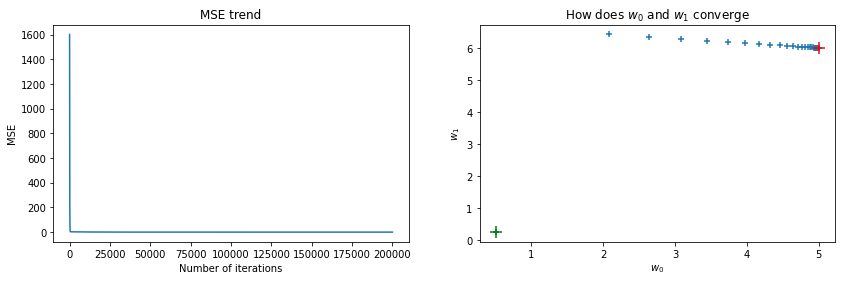

```python
get_gd_plots(j_history, w_0_history, w_1_history)
```

## 最後我們將 $h$ 還原為泛化的外觀：

$$ h(x) = w_0x_0 + w_1x_1 + w_2x_2 + ... + w_nx_n = w^Tx \text{, where } x_0 = 1 \\ h(X) = Xw $$

## 透過先前的經驗，我們知道可以利用梯度遞減求 $w$

$$ w_0 := w_0 - \alpha \frac{\mathrm \partial}{\mathrm \partial w_0} J(w) \\ w_1 := w_1 - \alpha \frac{\mathrm \partial}{\mathrm \partial w_1} J(w) \\ .\\ .\\ .\\ w_n := w_n - \alpha \frac{\mathrm \partial}{\mathrm \partial w_1} J(w) $$

## 利用梯度遞減求 $w$，寫成泛化的外觀：

$$ w_i := w_i - \alpha \frac{\mathrm \partial}{\mathrm \partial w_i} J(w) \\ \text{where } i = 0, 1, 2, ..., n $$

## 推導對 $w_i$ 偏微分的成本函數（梯度）

$$ J(w) = \frac{1}{m}(\hat{y} - y)^T(\hat{y} - y) = \frac{1}{m}(Xw - y)^T(Xw-y) \\ J(w) = \frac{1}{m}(w^TX^T-y^T)(Xw-y) = \frac{1}{m}(w^TX^TXw-w^TX^Ty-y^TXw+y^Ty) = \frac{1}{m}(w^TX^TXw-2w^TX^Ty+y^Ty)\\ \frac{\partial J}{\partial w} = \frac{1}{m}(2X^TXw - 2X^Ty) = \frac{2}{m}(X^T(Xw - y))\\ $$

## 梯度遞減（Gradient Descent）：從隨機指定的 $(w)$ 起始透過迭代、有意識地朝 $(w^*)$ 修正、更新

$$ w := w - \alpha\frac{2}{m}(X^T(Xw - y)) \\ w := w - \alpha\frac{2}{m}(X^T(\hat{y} - y)) $$

## 給定 $x_0$、$x_1$ 與 $y$，根據泛化的梯度遞減（Gradient Descent）演算法，找出 $w$

$$h(x) = Xw \text{ , where} x_0 = 1$$

```python
x_0 = np.array([1]*10)
x_1 = np.arange(10)
y = 5*x_0 + 6*x_1
print(x_0)
print(x_1)
print(y)
```

```
[1 1 1 1 1 1 1 1 1 1]
[0 1 2 3 4 5 6 7 8 9]
[ 5 11 17 23 29 35 41 47 53 59]
```

```python
def get_grad(X, y, w):
    m = y.size
    y_hat = X.dot(w)
    y_reshaped = y.reshape(-1, 1)
    err = y_hat - y_reshaped
    grad = (X.T.dot(err))*2/m
    return grad

X = np.concatenate([x_0.reshape(-1, 1), x_1.reshape(-1, 1)], axis=1)
n = X.shape[1]
w = np.random.rand(n, 1)
learning_rate = 0.0001
for i in range(100000):
    grad = get_grad(X, y, w)
    w -= learning_rate*grad
    if i % 5000 == 0:
        print("{} iterations: w_0 = {}; w_1 = {}".format(i, w[0, 0], w[1, 0]))
```

```
0 iterations: w_0 = 0.996460832541016; w_1 = 0.7673130828219514
5000 iterations: w_0 = 2.669813105481303; w_1 = 6.371605931667066
10000 iterations: w_0 = 3.2430544830233035; w_1 = 6.280188416329236
15000 iterations: w_0 = 3.6752746928214193; w_1 = 6.211260213992482
20000 iterations: w_0 = 4.001165874227485; w_1 = 6.159288805015069
25000 iterations: w_0 = 4.246885671013076; w_1 = 6.120102706153804
30000 iterations: w_0 = 4.432156773691804; w_1 = 6.090556646614949
35000 iterations: w_0 = 4.571849960552671; w_1 = 6.0682791130088525
40000 iterations: w_0 = 4.6771777001364425; w_1 = 6.051481999914357
45000 iterations: w_0 = 4.756594119613497; w_1 = 6.038817087662503
50000 iterations: w_0 = 4.816473574992249; w_1 = 6.02926782753399
55000 iterations: w_0 = 4.86162228857149; w_1 = 6.0220677485134155
60000 iterations: w_0 = 4.895664120197507; w_1 = 6.016638936521198
65000 iterations: w_0 = 4.921331436242277; w_1 = 6.012545648161078
70000 iterations: w_0 = 4.94068442289058; w_1 = 6.0094593357923465
75000 iterations: w_0 = 4.955276446908883; w_1 = 6.007132276665461
80000 iterations: w_0 = 4.966278736571915; w_1 = 6.005377689464609
85000 iterations: w_0 = 4.9745743902576525; w_1 = 6.004054742312194
90000 iterations: w_0 = 4.980829258306167; w_1 = 6.00305724890337
95000 iterations: w_0 = 4.985545387472839; w_1 = 6.002305145466096
```

```python
print(w)
```

```
[[4.9891007 ]
 [6.00173816]]
```

## 承接上題，將迭代過程的成本（MSE）記錄起來並作圖

```python
def get_mse(X, y, w):
    m = y.size
    y_hat = X.dot(w)
    y_reshaped = y.reshape(-1, 1)
    err = y_hat - y_reshaped
    se = err**2
    sse = se.sum()
    mse = sse / m
    return mse
```

```python
X = np.concatenate([x_0.reshape(-1, 1), x_1.reshape(-1, 1)], axis=1)
n = X.shape[1]
w = np.random.rand(n, 1)
learning_rate = 0.0001
w_0_history = []
w_1_history = []
j_history = []
for i in range(100000):
    mse = get_mse(X, y, w)
    j_history.append(mse)
    grad = get_grad(X, y, w)
    w -= learning_rate*grad
    if i % 5000 == 0:
        w_0_history.append(w[0, 0])
        w_1_history.append(w[1, 0])
        print("{} iterations: w_0 = {}; w_1 = {}".format(i, w[0, 0], w[1, 0]))
```

```
0 iterations: w_0 = 0.29275665425480574; w_1 = 0.5654708854837108
5000 iterations: w_0 = 2.176052314609618; w_1 = 6.450348301708087
10000 iterations: w_0 = 2.870762110243437; w_1 = 6.339559642888467
15000 iterations: w_0 = 3.394568704431035; w_1 = 6.256025726400961
20000 iterations: w_0 = 3.7895154143218295; w_1 = 6.193041705491096
25000 iterations: w_0 = 4.087302623158855; w_1 = 6.145552170021196
30000 iterations: w_0 = 4.31183221038208; w_1 = 6.10974537416142
35000 iterations: w_0 = 4.481126035108491; w_1 = 6.082747286750011
40000 iterations: w_0 = 4.608772459995977; w_1 = 6.062390907287059
45000 iterations: w_0 = 4.705017020675556; w_1 = 6.047042331718524
50000 iterations: w_0 = 4.777584783294563; w_1 = 6.035469607187054
55000 iterations: w_0 = 4.832300396668945; w_1 = 6.026743849380843
60000 iterations: w_0 = 4.873555607507573; w_1 = 6.020164685668299
65000 iterations: w_0 = 4.904661763801427; w_1 = 6.015204039714371
70000 iterations: w_0 = 4.928115600049261; w_1 = 6.011463745452748
75000 iterations: w_0 = 4.945799637560801; w_1 = 6.008643588301157
80000 iterations: w_0 = 4.959133284960941; w_1 = 6.00651720844883
85000 iterations: w_0 = 4.9691867669711955; w_1 = 6.004913932094595
90000 iterations: w_0 = 4.976767025957939; w_1 = 6.003705072320437
95000 iterations: w_0 = 4.982482491131819; w_1 = 6.002793600040742
```

```python
def get_gd_plots(j_history, w_0_history, w_1_history):
    fig, axes = plt.subplots(1, 2, figsize=(13, 3))
    axes[0].plot(range(len(j_history)), j_history)
    axes[0].set_xlabel("Number of iterations")
    axes[0].set_ylabel("MSE")
    axes[0].set_title("MSE trend")
    axes[1].scatter(w_0_history, w_1_history, marker="+")
    axes[1].scatter(w_0_history[0], w_1_history[0], marker="+", s=150, color="green")
    axes[1].scatter(w_0_history[-1], w_1_history[-1], marker="+", s=150, color="red")
    axes[1].set_xlabel("$w_0$")
    axes[1].set_ylabel("$w_1$")
    axes[1].set_title("How does $w_0$ and $w_1$ converge")
    plt.show()
```

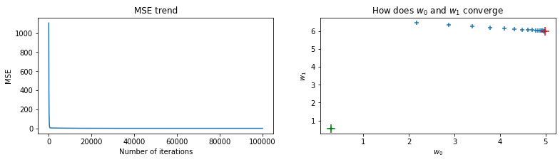

```python
get_gd_plots(j_history, w_0_history, w_1_history)
```

## 隨堂練習：在 NBA 球員資料集上應用梯度遞減求 $w$

```python
import pandas as pd
from sklearn.model_selection import train_test_split
from sklearn.linear_model import LinearRegression

csv_url = "https://pyml.s3-ap-northeast-1.amazonaws.com/nba/players.csv"
players = pd.read_csv(csv_url)
X = players["heightMeters"].values.reshape(-1, 1)
y = players["weightKilograms"].values
X_train, X_validation, y_train, y_validation = train_test_split(X, y, test_size=0.33, random_state=42)
lr = LinearRegression()
lr.fit(X_train, y_train)
w = lr.coef_.copy()
w = np.insert(w, 0, lr.intercept_).reshape(-1, 1)
print(w)
```

```
[[-104.53978433]
 [ 102.04130295]]
```

```python
def get_mse(X, y, w):
    m = y.size
    y_hat = X.dot(w)
    y_reshaped = y.reshape(-1, 1)
    err = y_hat - y_reshaped
    se = err**2
    sse = se.sum()
    mse = sse / m
    return mse

def get_grad(X, y, w):
    m = y.size
    y_hat = X.dot(w)
    y_reshaped = y.reshape(-1, 1)
    err = y_hat - y_reshaped
    grad = (X.T.dot(err))*2/m
    return grad
```

```python
from sklearn.preprocessing import PolynomialFeatures

poly = PolynomialFeatures(1)
X_train_poly = poly.fit_transform(X_train)
n = X_train_poly.shape[1]
w = np.random.rand(n, 1)
learning_rate = 0.01
j_history = []
for i in range(300000):
    mse = get_mse(X_train_poly, y_train, w)
    j_history.append(mse)
    grad = get_grad(X_train_poly, y_train, w)
    w -= learning_rate*grad
    if i % 10000 == 0:
        print("{} iterations: w_0 = {}; w_1 = {}".format(i, w[0, 0], w[1, 0]))
```

```
0 iterations: w_0 = 2.6161066186725104; w_1 = 4.774152220561014
10000 iterations: w_0 = -11.307656306317883; w_1 = 55.4304209275801
20000 iterations: w_0 = -34.79706472699367; w_1 = 67.17381955876093
30000 iterations: w_0 = -52.368424084085824; w_1 = 75.95852259284976
40000 iterations: w_0 = -65.51275978324743; w_1 = 82.52995985907936
50000 iterations: w_0 = -75.34544019579127; w_1 = 87.44575354913533
60000 iterations: w_0 = -82.70082173107774; w_1 = 91.1230354928247
70000 iterations: w_0 = -88.20304851560958; w_1 = 93.87384306246287
80000 iterations: w_0 = -92.31901441665447; w_1 = 95.93159724097049
90000 iterations: w_0 = -95.39798152615124; w_1 = 97.47090966176731
100000 iterations: w_0 = -97.70121694871763; w_1 = 98.62239935551563
110000 iterations: w_0 = -99.4241627364147; w_1 = 99.48377648526193
120000 iterations: w_0 = -100.71302020980191; w_1 = 100.12813358518106
130000 iterations: w_0 = -101.67715593511907; w_1 = 100.61014785962298
140000 iterations: w_0 = -102.398382072243; w_1 = 100.9707208412745
150000 iterations: w_0 = -102.93789858139378; w_1 = 101.24044910865325
160000 iterations: w_0 = -103.34148637260537; w_1 = 101.44222057219949
170000 iterations: w_0 = -103.64339206492862; w_1 = 101.59315663795645
180000 iterations: w_0 = -103.86923399831257; w_1 = 101.70606505198994
190000 iterations: w_0 = -104.03817608907646; w_1 = 101.79052670729835
200000 iterations: w_0 = -104.16455399243534; w_1 = 101.85370863469036
210000 iterations: w_0 = -104.2590915608125; w_1 = 101.90097216432859
220000 iterations: w_0 = -104.32981082104087; w_1 = 101.9363278637524
230000 iterations: w_0 = -104.38271268696623; w_1 = 101.96277585634415
240000 iterations: w_0 = -104.42228616962643; w_1 = 101.98256039811635
250000 iterations: w_0 = -104.45188929425065; w_1 = 101.9973603150391
260000 iterations: w_0 = -104.47403404696445; w_1 = 102.00843146055497
270000 iterations: w_0 = -104.49059953047268; w_1 = 102.01671328157282
280000 iterations: w_0 = -104.50299141614467; w_1 = 102.02290853564786
290000 iterations: w_0 = -104.5122612228743; w_1 = 102.02754292378192
```

```python
print(w)
```

```
[[-104.51919495]
 [ 102.0310094 ]]
```

## 已經有了正規方程可以得到 $w^*$ 為什麼還需要梯度遞減？

原因是因為使用正規方程（normal equations）求解，在變數個數增多的時候會遭遇計算複雜性的議題。

## 計算複雜性

## 什麼是計算複雜性？

> 計算複雜性（Computational Complexity）是研究解決問題所需的資源，諸如時間（要通過多少步演算才能解決問題）和空間（在解決問題時需要多少記憶體），在演算法中常見到所謂的大 O 符號就是用來表示演算所需時間資源的表達式。

## 正規方程 normal equations 需要計算 $X^TX$ 的反矩陣

$$w = (X^{(train)T}X^{(train)})^{-1}X^{(train)T}y^{(train)}$$

## 為何計算 $X^TX$ 的反矩陣是在變數個數 $n$ 增多時才有計算複雜性的議題？$m$ 呢？

$X$ 的外觀為 $m \times n$，$X^T$ 的外觀為 $n \times m$，$X^TX$ 的外觀為 $n \times n$

## 計算 $n$ 很大的 $n \times n$ 反矩陣為何會產生計算複雜性議題？

## 這要先將時間拉回到 2005 年

[figure not shown]

Source: https://www.screengeek.net/2019/05/13/avengers-endgame-directors-time-travel/

## 為何是 2005 年？

> NumPy 1.0 was relased in 2006. This new project was part of SciPy.

Source: https://en.wikipedia.org/wiki/NumPy

## 利用 Vanilla Python 計算 $A$ 的反矩陣 $A^{-1}$

$$ A = \begin{bmatrix} a & b \\ c & d \\ \end{bmatrix} \\ A^{-1} = \frac{1}{ad-bc}\begin{bmatrix} d & -b \\ -c & a \\ \end{bmatrix} = \frac{1}{det(A)}\begin{bmatrix} d & -b \\ -c & a \\ \end{bmatrix}\\ $$

## 在 Vanilla Python 計算一個 $2 \times 2$ 矩陣 $A$ 的反矩陣其實已經有點辛苦了...

## 計算 $3 \times 3$ 的反矩陣要計算 9 個 $2 \times 2$ 矩陣的行列式（determinant）

[figure not shown]

Source: http://mathworld.wolfram.com/MatrixInverse.html

## 以此類推 $4 \times 4$ 的反矩陣我們要計算 16 個 $3 \times 3$ 矩陣的行列式，$n \times n$ 的反矩陣就要計算 $n^2$ 個 $(n-1) \times (n-1)$ 矩陣的行列式

## `NumPy` 底層還是用 C 語言與 Python 實作，使用封裝好的函數並不代表計算複雜性的問題不存在

## 什麼時候 $n$ 會很大呢？

- 一張 28 x 28 的圖片，n 就是 784
- 一張 224 x 224 x 3 的圖片，n 就是 150528

```
(28, 28)
```

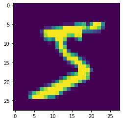

```python
import tensorflow as tf

(x_train, y_train), (x_test, y_test) = tf.keras.datasets.mnist.load_data(path="mnist.npz")
first_img = x_train[0]
print(first_img.shape)
fig, ax = plt.subplots()
ax.imshow(first_img)
plt.show()
```

```
(224, 224, 3)
```

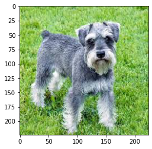

```python
from tensorflow.keras.preprocessing.image import load_img
from tensorflow.keras.preprocessing import image

#!wget --output-document=schnauzer.jpeg https://i.imgur.com/LWBF92t.jpg
schnauzer = load_img("schnauzer.jpeg", target_size=(224, 224))
x = image.img_to_array(schnauzer)
print(x.shape)
fig, ax = plt.subplots()
ax.imshow(schnauzer)
plt.show()
```

## 因此機器學習、深度學習更傾向使用梯度遞減的方法尋找 $w$，而非正規方程

## 進階的梯度遞減

## 在 Housing 資料集上應用梯度遞減求 $w$

- `X` 為 `GrLivArea`
- `y` 為 `SalePrice`

```python
import pandas as pd
from sklearn.model_selection import train_test_split
from sklearn.linear_model import LinearRegression

csv_url = "https://kaggle-getting-started.s3-ap-northeast-1.amazonaws.com/house-prices/train.csv"
housing = pd.read_csv(csv_url)
X = housing["GrLivArea"].values.reshape(-1, 1)
y = housing["SalePrice"].values
X_train, X_validation, y_train, y_validation = train_test_split(X, y, test_size=0.33, random_state=42)
lr = LinearRegression()
lr.fit(X_train, y_train)
w = lr.coef_.copy()
w = np.insert(w, 0, lr.intercept_).reshape(-1, 1)
print(w)
```

```
[[30774.03773616]
 [   98.50395317]]
```

## 使用 Gradient Descent 找出 $w$

```python
def get_mse(X, y, w):
    m = y.size
    y_hat = X.dot(w)
    y_reshaped = y.reshape(-1, 1)
    err = y_hat - y_reshaped
    se = err**2
    sse = se.sum()
    mse = sse / m
    return mse

def get_grad(X, y, w):
    m = y.size
    y_hat = X.dot(w)
    y_reshaped = y.reshape(-1, 1)
    err = y_hat - y_reshaped
    grad = (X.T.dot(err))*2/m
    return grad
```

```python
def gradient_descent(X, y, epochs, learning_rate):
    n = X.shape[1]
    w = np.random.rand(n, 1)
    j_history = []
    w_0_history, w_1_history = [w[0, 0]], [w[1, 0]]
    n_prints = 20
    interval = epochs // n_prints
    for i in range(epochs):
        mse = get_mse(X, y, w)
        j_history.append(mse)
        grad = get_grad(X, y, w)
        w -= learning_rate*grad
        if i % interval == 0:
            w_0_history.append(w[0, 0])
            w_1_history.append(w[1, 0])
            print("{} iterations: w_0 = {}; w_1 = {}".format(i, w[0, 0], w[1, 0]))
    return w, w_0_history, w_1_history, j_history
```

```python
from sklearn.preprocessing import PolynomialFeatures

poly = PolynomialFeatures(1)
X_poly = poly.fit_transform(X)
X_train, X_validation, y_train, y_validation = train_test_split(X_poly, y, test_size=0.33, random_state=42)
n_epochs = 300000
learning_rate = 1e-7
w, w_0_history, w_1_history, j_history = gradient_descent(X_train, y_train, n_epochs, learning_rate)
```

```
0 iterations: w_0 = 0.6930513365459056; w_1 = 60.63749949432665
15000 iterations: w_0 = 10.437865908946563; w_1 = 116.54776208731936
30000 iterations: w_0 = 20.146818930302793; w_1 = 116.5420674841579
45000 iterations: w_0 = 29.85270781842485; w_1 = 116.53637467820596
60000 iterations: w_0 = 39.55553354034895; w_1 = 116.53068366889634
75000 iterations: w_0 = 49.25529706280707; w_1 = 116.52499445566202
90000 iterations: w_0 = 58.95199935222456; w_1 = 116.51930703793619
105000 iterations: w_0 = 68.64564137472341; w_1 = 116.51362141515214
120000 iterations: w_0 = 78.3362240961195; w_1 = 116.50793758674344
135000 iterations: w_0 = 88.02374848192441; w_1 = 116.50225555214374
150000 iterations: w_0 = 97.70821549734467; w_1 = 116.49657531078695
165000 iterations: w_0 = 107.38962610728353; w_1 = 116.4908968621071
180000 iterations: w_0 = 117.06798127633847; w_1 = 116.48522020553845
195000 iterations: w_0 = 126.74328196880106; w_1 = 116.4795453405154
210000 iterations: w_0 = 136.41552914866242; w_1 = 116.47387226647253
225000 iterations: w_0 = 146.0847237796073; w_1 = 116.46820098284462
240000 iterations: w_0 = 155.75086682501407; w_1 = 116.46253148906662
255000 iterations: w_0 = 165.41395924795822; w_1 = 116.45686378457364
270000 iterations: w_0 = 175.0740020112175; w_1 = 116.451197868801
285000 iterations: w_0 = 184.73099607725703; w_1 = 116.44553374118419
```

```python
print(w)
```

```
[[194.38429891]
 [116.43987178]]
```

```python
def get_gd_plots(j_history, w_0_history, w_1_history, best_w_0, best_w_1):
    fig, axes = plt.subplots(1, 2, figsize=(12, 3))
    axes[0].plot(range(len(j_history)), j_history)
    axes[0].set_xlabel("Number of iterations")
    axes[0].set_ylabel("MSE")
    axes[0].set_title("MSE trend")
    axes[1].scatter(w_0_history, w_1_history, marker="+")
    axes[1].scatter(best_w_0, best_w_1, marker="x", s=200, color="red")
    axes[1].scatter(w_0_history[-1], w_1_history[-1], marker="x", s=200, color="green")
    axes[1].set_xlabel("$w_0$")
    axes[1].set_ylabel("$w_1$")
    axes[1].set_title("How does $w_0$ and $w_1$ converge")
    #axes[1].set_ylim(0, 15)
    plt.show()
```

## 發生什麼事情了，離最佳解這麼遠？

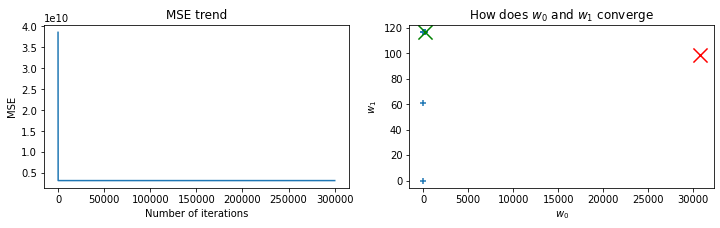

```python
get_gd_plots(j_history, w_0_history, w_1_history, 30774, 98.5)
```

## 這是因為 $w_0$ 與 $w_1$ 的量級（scale）差距緣故

```python
def get_contour_plot(w_0_history, w_1_history, w_0_min, w_0_max, w_1_min, w_1_max):
    w_0_arr, w_1_arr = np.meshgrid(np.linspace(w_0_min, w_0_max, 100), np.linspace(w_1_min, w_1_max, 100))
    mse_arr = np.zeros((100, 100))
    for i in range(100):
        for j in range(100):
            w_arr = np.array([w_0_arr[i, j], w_1_arr[i, j]]).reshape(-1, 1)
            mse = get_mse(X_train, y_train, w_arr)
            mse_arr[i, j] = mse
    fig, ax = plt.subplots()
    CS = ax.contour(w_0_arr, w_1_arr, mse_arr)
    ax.clabel(CS, inline=1, fontsize=10)
    ax.scatter(w_0_history, w_1_history, marker="+", color="blue", s=100)
    ax.scatter(30774.03773616, 98.50395317, marker="x", s=200, color="red")
    plt.show()
```

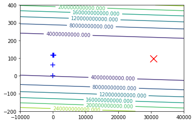

```python
get_contour_plot(w_0_history, w_1_history, -10000, 40000, -200, 400)
```

## 該如何解決這樣的問題？

- 標準化（Standardization）
- 使用進階的梯度遞減演算法
  - 動量梯度遞減
  - 調適梯度遞減
  - RMSprop 梯度遞減
  - Adam 梯度遞減

## 常見的標準化方法有兩個

1. MinMax scaler

$$X_{scaled} = \frac{X-X_{min}}{X_{max} - X_{min}}$$

1. Standard scaler:

$$X_{scaled} = \frac{X-\mu_X}{\sigma_X}$$

## 自己寫 Standard scaler

```python
print(X[:5])
```

```
[[1710]
 [1262]
 [1786]
 [1717]
 [2198]]
```

```python
def get_standard_scaled(X):
    X_mu = X.mean(axis=0)
    X_std = X.std(axis=0)
    X_standard_scaled = (X - X_mu)/X_std
    return X_standard_scaled
```

```python
X_standard_scaled = get_standard_scaled(X)
print(X_standard_scaled[:5])
```

```
[[ 0.37033344]
 [-0.48251191]
 [ 0.51501256]
 [ 0.38365915]
 [ 1.2993257 ]]
```

## 以 `sklearn.preprocessing.StandardScaler()` 做標準化

```python
from sklearn.preprocessing import StandardScaler

ss = StandardScaler()
X_standard_scaled = ss.fit_transform(X.astype(float))
print(X_standard_scaled[:5])
```

```
[[ 0.37033344]
 [-0.48251191]
 [ 0.51501256]
 [ 0.38365915]
 [ 1.2993257 ]]
```

```python
poly = PolynomialFeatures(1)
X_poly = poly.fit_transform(X_standard_scaled)
X_train, X_validation, y_train, y_validation = train_test_split(X_poly, y, test_size=0.33, random_state=42)
n_epochs = 400000
learning_rate = 0.00001
w, w_0_history, w_1_history, j_history = gradient_descent(X_train, y_train, n_epochs, learning_rate)
```

```
0 iterations: w_0 = 3.6564649606858746; w_1 = 1.6441391861449874
20000 iterations: w_0 = 59626.171989722265; w_1 = 17878.385699629558
40000 iterations: w_0 = 99501.15742778247; w_1 = 29592.141719163097
60000 iterations: w_0 = 126170.42626494089; w_1 = 37263.43058517282
80000 iterations: w_0 = 144008.26224319026; w_1 = 42284.46083346214
100000 iterations: w_0 = 155939.72975312412; w_1 = 45568.866223088145
120000 iterations: w_0 = 163920.8959313733; w_1 = 47715.936041073604
140000 iterations: w_0 = 169259.89433193818; w_1 = 49118.57544445104
160000 iterations: w_0 = 172831.58901210545; w_1 = 50034.24778091114
180000 iterations: w_0 = 175221.1059491222; w_1 = 50631.57280202756
200000 iterations: w_0 = 176819.8071442852; w_1 = 51020.921486046216
220000 iterations: w_0 = 177889.4678333649; w_1 = 51274.49461692214
240000 iterations: w_0 = 178605.19329690537; w_1 = 51439.49368106652
260000 iterations: w_0 = 179084.11966187393; w_1 = 51546.75632622933
280000 iterations: w_0 = 179404.60857667433; w_1 = 51616.41527284726
300000 iterations: w_0 = 179619.0849283299; w_1 = 51661.60466640047
320000 iterations: w_0 = 179762.62332519572; w_1 = 51690.88621262595
340000 iterations: w_0 = 179858.6914222222; w_1 = 51709.8363532731
360000 iterations: w_0 = 179922.9916991667; w_1 = 51722.08394509078
380000 iterations: w_0 = 179966.03139529497; w_1 = 51729.988235592995
```

```python
print(w)
```

```
[[179994.8405646 ]
 [ 51735.08131238]]
```

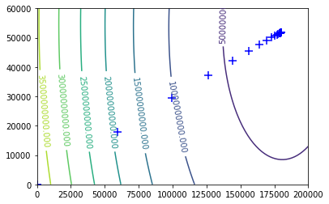

```python
get_contour_plot(w_0_history, w_1_history, 0, 200000,  0, 60000)
```

## 逆「標準化」

$$ \hat{y} = X^{scaled}w' = w_0'x_0 + w_1'x_1^{scaled} \\ \hat{y} = w_0'x_0 + w_1'\frac{x_1 - \mu_{x_1}}{\sigma_{x_1}}\\ \hat{y} = w_0' - w_1'\frac{\mu_{x_1}}{\sigma_{x_1}} + \frac{w_1'}{\sigma_{x_1}}x_1 $$$$ w_0 = w_0' - w_1'\frac{\mu_{x_1}}{\sigma_{x_1}}\\ w_1 = \frac{w_1'}{\sigma_{x_1}} $$

```python
X_mu = X.mean(axis=0)
X_std = X.std(axis=0)
w_0 = w[0, 0] - w[1, 0]*X_mu[0]/X_std[0]
w_1 = w[1, 0]/X_std[0]
w_rescaled = np.array([w_0, w_1]).reshape(-1, 1)
print(w_rescaled)
```

```
[[30741.88238022]
 [   98.4866601 ]]
```

## 除了將 $X$ 標準化，亦可以採用進階梯度遞減演算法，常見的包含

- 動量梯度遞減
- 調適梯度遞減
- RMSProp 梯度遞減
- Adam 梯度遞減
- ...etc.

## 動量梯度遞減（Gradient Descent with Momentum）

> 具有動量的梯度下降在每次迭代更新係數時會將前一次更新的動量（Momentum, $V$）以 $\gamma$ 與當下的梯度加權；這會使得如果當下梯度的正負號與之前相同，更新的幅度會增強；若當下梯度的正負號與之前不一致，更新的幅度則會衰退。

## 每次迭代更新係數時會將前一次更新的動量（Momentum, $V$）以 $\gamma$ 與當下的梯度加權

$$ v_t := \gamma v_{t-1} + (1-\gamma) \nabla J(w) \\ w := w - \alpha v_t \\ \text{where, } \gamma = 0.9 $$

```python
def momentum(X, y, epochs, learning_rate, gamma=0.9):
    n = X.shape[1]
    w = np.random.rand(n, 1)
    j_history = []
    w_0_history, w_1_history = [w[0, 0]], [w[1, 0]]
    n_prints = 20
    interval = epochs // n_prints
    # Initiate velocities
    velocity_values = np.array([0, 0], dtype=float).reshape(-1, 1)
    velocities = {i: velocity_values for i in range(epochs)}
    for i in range(epochs):
        mse = get_mse(X_train, y_train, w)
        j_history.append(mse)
        grad = get_grad(X_train, y_train, w)
        # Use velocities to update w
        if i == 0:
            velocities[i] = (1-gamma) * grad
        else:
            velocities[i] = gamma * velocities[i-1] + (1 - gamma) * grad
        w -= learning_rate*velocities[i]
        if i % interval == 0:
            print("{} iterations: w_0 = {}; w_1 = {}".format(i, w[0, 0], w[1, 0]))
            w_0_history.append(w[0, 0])
            w_1_history.append(w[1, 0])
    return w, w_0_history, w_1_history, j_history
```

```python
X = housing["GrLivArea"].values.reshape(-1, 1)
y = housing["SalePrice"].values
poly = PolynomialFeatures(1)
X_poly = poly.fit_transform(X)
X_train, X_validation, y_train, y_validation = train_test_split(X_poly, y, test_size=0.33, random_state=42)
n_epochs = 4000000
learning_rate = 0.000005
w, w_0_history, w_1_history, j_history = momentum(X_train, y_train, n_epochs, learning_rate)
```

```
0 iterations: w_0 = 1.0929708207100404; w_1 = 302.13971669995345
200000 iterations: w_0 = 5840.507699225873; w_1 = 113.12824465518098
400000 iterations: w_0 = 10572.089972892887; w_1 = 110.35302436983561
600000 iterations: w_0 = 14405.770073088075; w_1 = 108.10445165858881
800000 iterations: w_0 = 17511.940960664015; w_1 = 106.28258574601129
1000000 iterations: w_0 = 20028.660491418486; w_1 = 104.80645140229593
1200000 iterations: w_0 = 22067.787579311214; w_1 = 103.61043989252855
1400000 iterations: w_0 = 23719.95391320941; w_1 = 102.64139291005993
1600000 iterations: w_0 = 25058.592201659154; w_1 = 101.8562398855588
1800000 iterations: w_0 = 26143.19998632167; w_1 = 101.22008365883711
2000000 iterations: w_0 = 27021.984088569574; w_1 = 100.70464942860714
2200000 iterations: w_0 = 27734.003225149805; w_1 = 100.28702804170055
2400000 iterations: w_0 = 28310.904024287534; w_1 = 99.94865776558608
2600000 iterations: w_0 = 28778.327601755696; w_1 = 99.67449928772174
2800000 iterations: w_0 = 29157.049214032104; w_1 = 99.4523672735037
3000000 iterations: w_0 = 29463.90164193539; w_1 = 99.27238877302109
3200000 iterations: w_0 = 29712.523345735593; w_1 = 99.12656440479577
3400000 iterations: w_0 = 29913.96464448318; w_1 = 99.00841281273706
3600000 iterations: w_0 = 30077.178861989287; w_1 = 98.91268259373601
3800000 iterations: w_0 = 30209.420269098577; w_1 = 98.83511889213555
```

```python
print(w)
```

```
[[30316.56602797]
 [   98.77227457]]
```

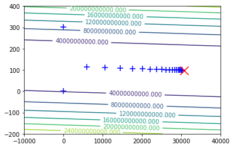

```python
get_contour_plot(w_0_history, w_1_history, -10000, 40000, -200, 400)
```

## 在梯度遞減迭代的過程動態地調整學習速率（Learning rate）的值

$$ ssg = \sum^{t-1} \nabla J^2(w)\\ w := w - \alpha \frac{1}{\epsilon + \sqrt{ssg}} \nabla J(w)\\ \text{where, } \epsilon = 1e^{-8} $$

```python
def adagrad(X, y, epochs, learning_rate, epsilon=1e-8):
    n = X.shape[1]
    w = np.random.rand(n, 1)
    j_history = []
    w_0_history, w_1_history = [w[0, 0]], [w[1, 0]]
    n_prints = 20
    interval = epochs // n_prints
    # Initiate sum of squared gradients
    ssg = np.array([0, 0], dtype=float).reshape(-1, 1)
    for i in range(epochs):
        mse = get_mse(X, y, w)
        j_history.append(mse)
        grad = get_grad(X, y, w)
        # Use adaptive gradient to update w
        ssg += grad**2
        ada_grad = grad / (epsilon + ssg**0.5)
        w -= learning_rate*ada_grad
        if i % interval == 0:
            print("{} iterations: w_0 = {}; w_1 = {}".format(i, w[0, 0], w[1, 0]))
            w_0_history.append(w[0, 0])
            w_1_history.append(w[1, 0])
    return w, w_0_history, w_1_history, j_history
```

```python
n_epochs = 200000
learning_rate = 100
w, w_0_history, w_1_history, j_history = adagrad(X_train, y_train, n_epochs, learning_rate)
```

```
0 iterations: w_0 = 100.51781124031433; w_1 = 100.68063418184454
10000 iterations: w_0 = 10320.008026806232; w_1 = 110.50134008699698
20000 iterations: w_0 = 15671.021133790298; w_1 = 107.36263728844581
30000 iterations: w_0 = 19296.896197997117; w_1 = 105.23586353551319
40000 iterations: w_0 = 21937.400324443475; w_1 = 103.68707187738205
50000 iterations: w_0 = 23923.412318362658; w_1 = 102.52217663158909
60000 iterations: w_0 = 25442.46185975996; w_1 = 101.63117947119638
70000 iterations: w_0 = 26615.298564465054; w_1 = 100.94325370863012
80000 iterations: w_0 = 27525.77518187436; w_1 = 100.40921515432082
90000 iterations: w_0 = 28234.868470658377; w_1 = 99.9932977787541
100000 iterations: w_0 = 28788.194530419754; w_1 = 99.66874544404247
110000 iterations: w_0 = 29220.478725585337; w_1 = 99.41519000879244
120000 iterations: w_0 = 29558.44088631286; w_1 = 99.21695898813165
130000 iterations: w_0 = 29822.776799813506; w_1 = 99.06191329973251
140000 iterations: w_0 = 30029.58129028086; w_1 = 98.9406125525491
150000 iterations: w_0 = 30191.40215527829; w_1 = 98.84569685947118
160000 iterations: w_0 = 30318.036753358112; w_1 = 98.77141959902032
170000 iterations: w_0 = 30417.142022661978; w_1 = 98.71328960949904
180000 iterations: w_0 = 30494.705514158653; w_1 = 98.66779490508696
190000 iterations: w_0 = 30555.41099423853; w_1 = 98.63218823223862
```

```python
print(w)
```

```
[[30602.9189352 ]
 [   98.60432255]]
```

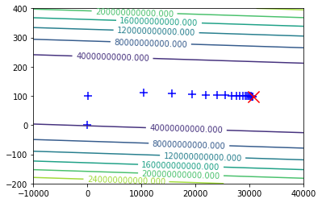

```python
get_contour_plot(w_0_history, w_1_history, -10000, 40000, -200, 400)
```

## RMSProp 梯度遞減（Gradient Descent with Root Mean Square Propagation）

> 和調適梯度遞減同樣是在迭代的過程動態地調整學習速率（Learning rate）的值，但 AdaGrad 所採用的梯度平方和是單調遞增的數值（monotonic increasing），有可能造成學習速率下降過快；RMSProp 利用 $1-\gamma$ 去降低梯度平方和的影響力。

## 利用 $1-\gamma$ 去降低梯度平方和的影響力

$$ ssg = \sum^{t-1} \nabla J^2(w) \\ v_t := \gamma v_{t-1} + (1-\gamma)ssg \\ w := w - \alpha \frac{1}{\epsilon + \sqrt{v_t}} \nabla J(w)\\ \text{where, } \epsilon = 1e^{-8} \text{, }\gamma = 0.9 $$

```python
def RMSProp(X, y, epochs, learning_rate, epsilon=1e-8, gamma=0.9):
    n = X.shape[1]
    w = np.random.rand(n, 1)
    j_history = []
    w_0_history, w_1_history = [w[0, 0]], [w[1, 0]]
    n_prints = 20
    interval = epochs // n_prints
    # Initiate velocities
    velocity_values = np.array([0, 0], dtype=float).reshape(-1, 1)
    velocities = {i: velocity_values for i in range(epochs)}
    # Initiate sum of squared gradients
    ssg = np.array([0, 0], dtype=float).reshape(-1, 1)
    for i in range(epochs):
        mse = get_mse(X, y, w)
        j_history.append(mse)
        grad = get_grad(X, y, w)
        # Use adaptive velocities to update w
        ssg += grad**2
        if i == 0:
            velocities[i] = (1-gamma)*ssg
            ada_grad = grad / (epsilon + velocities[i]**0.5)
        else:
            velocities[i] = gamma * velocities[i-1] + (1-gamma)*ssg
            ada_grad = grad / (epsilon + velocities[i]**0.5)
        w -= learning_rate*ada_grad
        if i % interval == 0:
            print("{} iterations: w_0 = {}; w_1 = {}".format(i, w[0, 0], w[1, 0]))
            w_0_history.append(w[0, 0])
            w_1_history.append(w[1, 0])
    return w, w_0_history, w_1_history, j_history
```

```python
n_epochs = 300000
learning_rate = 100
w, w_0_history, w_1_history, j_history = RMSProp(X_train, y_train, n_epochs, learning_rate)
```

```
0 iterations: w_0 = 317.1322789378848; w_1 = 317.08091677709297
15000 iterations: w_0 = 9502.62660494628; w_1 = 110.98093289651023
30000 iterations: w_0 = 15086.778230880083; w_1 = 107.7054405705682
45000 iterations: w_0 = 18951.605399926037; w_1 = 105.43847973745544
60000 iterations: w_0 = 21771.99092682423; w_1 = 103.7841577219454
75000 iterations: w_0 = 23882.043760358774; w_1 = 102.54649103231844
90000 iterations: w_0 = 25481.43140196901; w_1 = 101.60836009967264
105000 iterations: w_0 = 26702.56491374686; w_1 = 100.89209712696307
120000 iterations: w_0 = 27638.7724973171; w_1 = 100.34295938627263
135000 iterations: w_0 = 28358.265923880124; w_1 = 99.92093665512989
150000 iterations: w_0 = 28911.991969746254; w_1 = 99.59614572573686
165000 iterations: w_0 = 29338.49779936382; w_1 = 99.3459765094004
180000 iterations: w_0 = 29667.174708076163; w_1 = 99.15318936769097
195000 iterations: w_0 = 29920.536105678493; w_1 = 99.00457893400059
210000 iterations: w_0 = 30115.874277612154; w_1 = 98.89000232479147
225000 iterations: w_0 = 30266.49287590441; w_1 = 98.80165621255246
240000 iterations: w_0 = 30382.636859436203; w_1 = 98.7335313631268
255000 iterations: w_0 = 30472.200279099605; w_1 = 98.68099748004184
270000 iterations: w_0 = 30541.267826076364; w_1 = 98.64048555628968
285000 iterations: w_0 = 30594.530503604612; w_1 = 98.60924405978417
```

```python
print(w)
```

```
[[30635.60288952]
 [   98.58515284]]
```

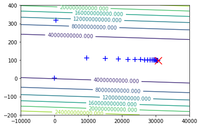

```python
get_contour_plot(w_0_history, w_1_history, -10000, 40000, -200, 400)
```

## Adam 梯度遞減（Gradient Descent with Adaptive Moment Estimation）

> 結合動量梯度遞減與 RMSProp 梯度遞減的特性，是目前最被廣泛使用的梯度遞減演算法。

[figure not shown]

Source: https://wiki.komica.org/